# Pan-cancer dual TCR analysis

## Results

### Frequency of dual TCR

There are a total of 168,901 cells with TCRs across all samples. 85.8% of these are expressing a single alpha and beta TCR allele that is expected to be productive (translated). Of the remaining **14.2%** of cells expressing more than one alpha or beta chain allele, the majority of these expressed two alpha chain alleles and one beta chain allele (9.3%), while 3.2% expressed one alpha chain allele and two beta chain alleles. This is consistent with prior observations where co-expression of two alpha chain alleles was more frequently observed than beta chain alleles. Cells expressing two alpha chain and two beta chain alleles (1.7% of cells in dataset) were excluded because it was not possible to determine whether these were doublets that made it through initial quality control settings or true expression values.

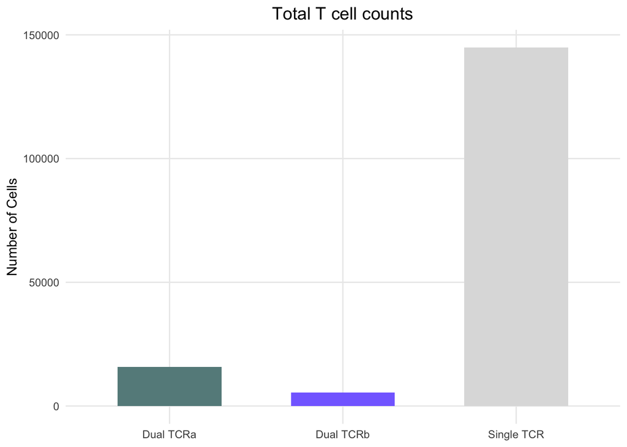

### Frequency of unique clones

There are 95,102 unique TCR clones from 168,901 total T cells in this dataset. 82.6% of unique clones are expressing a single alpha and beta TCR allele that is expected to be productive (translated). Of the remaining **17.4%** of unique clones expressing more than one alpha or beta chain allele, the majority of these (10.6% of unique clones) are expressing two alpha chain alleles and one beta chain allele.

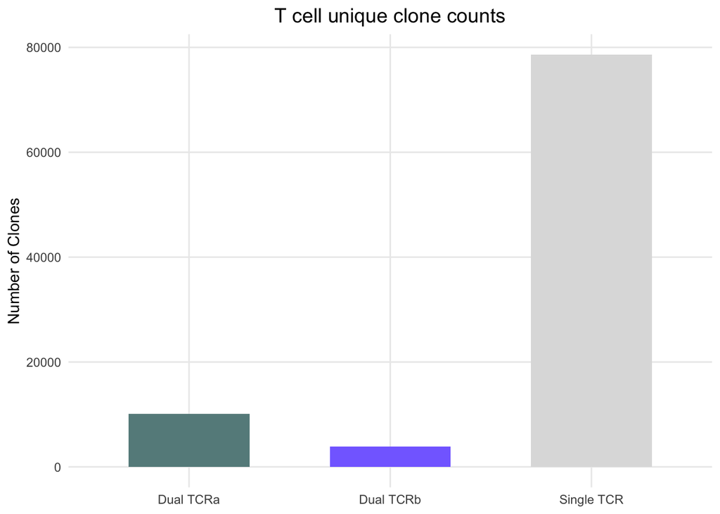

### Clonal expansion

Using the pre-calculated clone size measures, clone sizes were compared across TCR allele count groups.

#### All unique clones

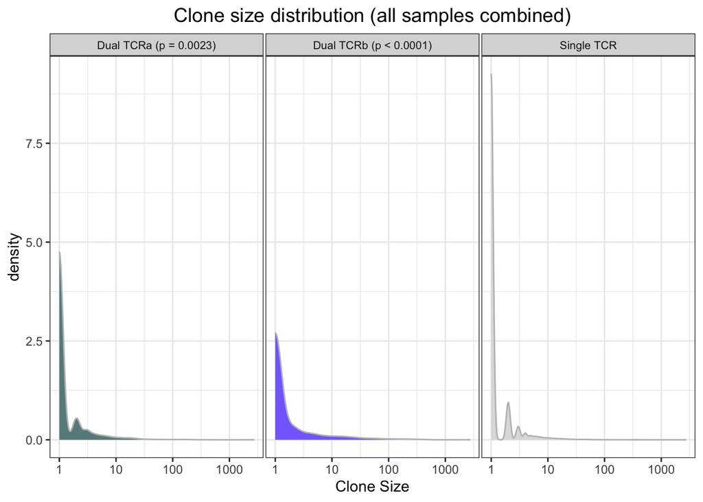

(p-value indicates difference in mean clone size compared to single TCR population as computed by Welch’s One-Way ANOVA with Games-Howell posttest)

#### By Tissue Type

Interestingly, the mean clone size of dual expressing T cell clones in tumor is greater than the mean clone size of single TCR expressing clones (1.7X and 3.7X TCRa and TCRb, respectively). In other words, dual expressing clones in the tumor are more expanded compared to single expressing clones. Further, The mean clone size is larger in tissues (normal or cancer) than in peripheral blood. In future sections, analysis will combine normal and cancer tissues when comparing with peripheral blood.

##### Statistical Comparisons Between Tissue Types

-The mean clone size of dual TCRa expressing clones is greater in tissue (normal and tumor) compared to the peripheral blood, however, mean clone size is not significantly different between normal and tumor tissues.

-The mean clone size of dual TCRb expressing clones is greater in tissue (normal and tumor) compared to the peripheral blood, however, mean clone size is not significantly different between normal and tumor tissues.

-The mean clone size of single TCR expressing clones is greater in tissue (normal and tumor) compared to the peripheral blood, however, mean clone size is not significantly different between normal and tumor tissues. It is interesting to note that the mean clone size in tumor versus normal tissue is approaching significance (p=0.08).

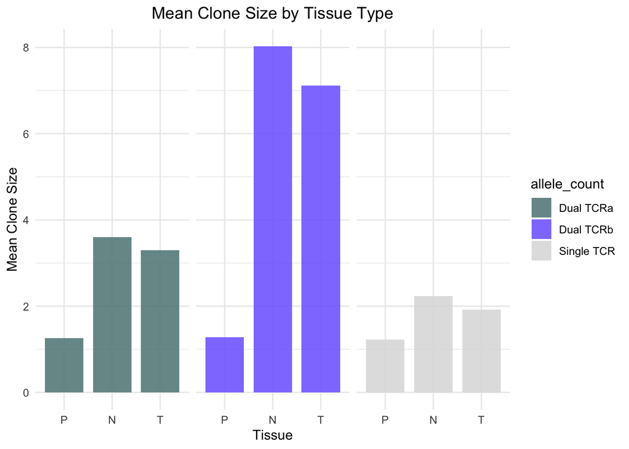

```r
# Dual TCRa
uniq_a <- bind_rows(uniq_pa, uniq_na, uniq_ta)
jmv_a <- anovaOneW(data = uniq_a, deps = cloneSize, group = loc, phMethod = "gamesHowell")
jmv_a  # pvalue T vs N (0.9296394)

# Dual TCRb
uniq_b <- bind_rows(uniq_pb, uniq_nb, uniq_tb)
jmv_b <- anovaOneW(data = uniq_b, deps = cloneSize, group = loc, phMethod = "gamesHowell")
jmv_b # pvalue T vs N (0.9349664)

# Single TCR
uniq_s <- bind_rows(uniq_ps, uniq_ns, uniq_ts)
jmv_s <- anovaOneW(data = uniq_s, deps = cloneSize, group = loc, phMethod = "gamesHowell")
jmv_s # pvalue T vs N (0.0786585)
```

#### By T cell subset

Because dual TCR cell frequencies and mean expansion differed greatly between peripheral blood and tissues, tissue (combined normal and tumor) and peripheral blood are evaluated separately here.

**Summary of results in this section:**  
* In all cases, CD4+ clones were less clonally expanded than CD8+ clones.  
* In tissues, the mean clone size of unique CD4+ T cell clones was not significantly increased compared to the single TCR subpopulation (p = 0.08).  
* In tissues, mean clone size of unique CD8+ T cell clones was significantly increased compared to the single TCR subpopulation (p = 0.0058).  
* the number of expanded unique dual TCRa (1.9X) and dual TCRb (4.1X) expressing CD8+ clones was significantly greater compared to single TCR expressing CD8+ clones.

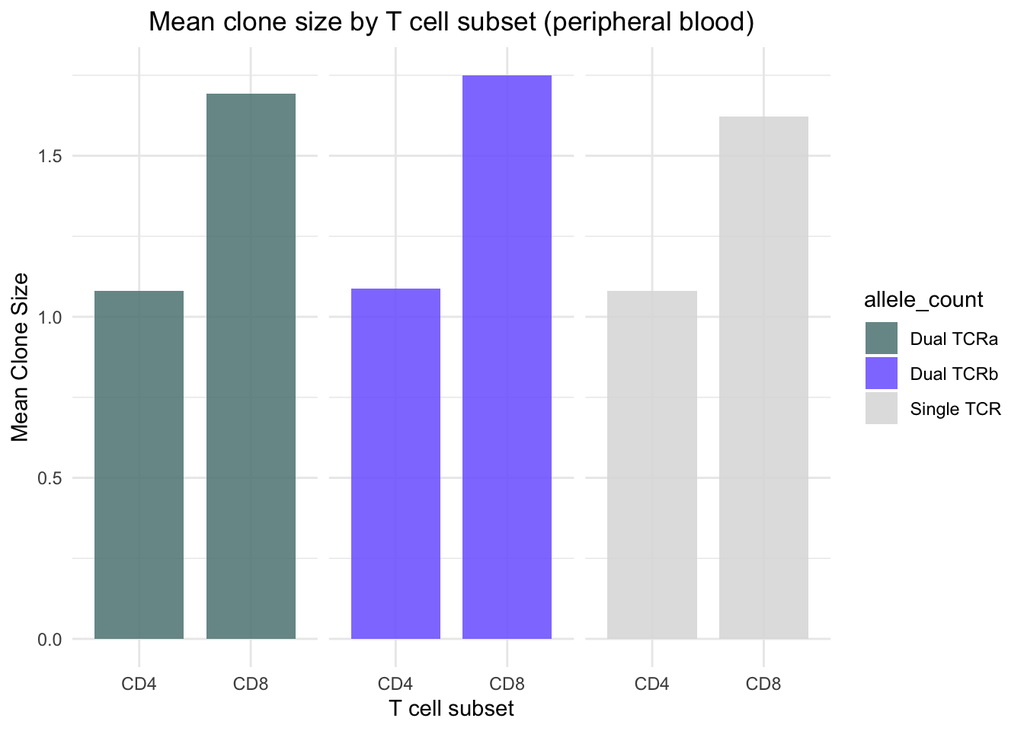

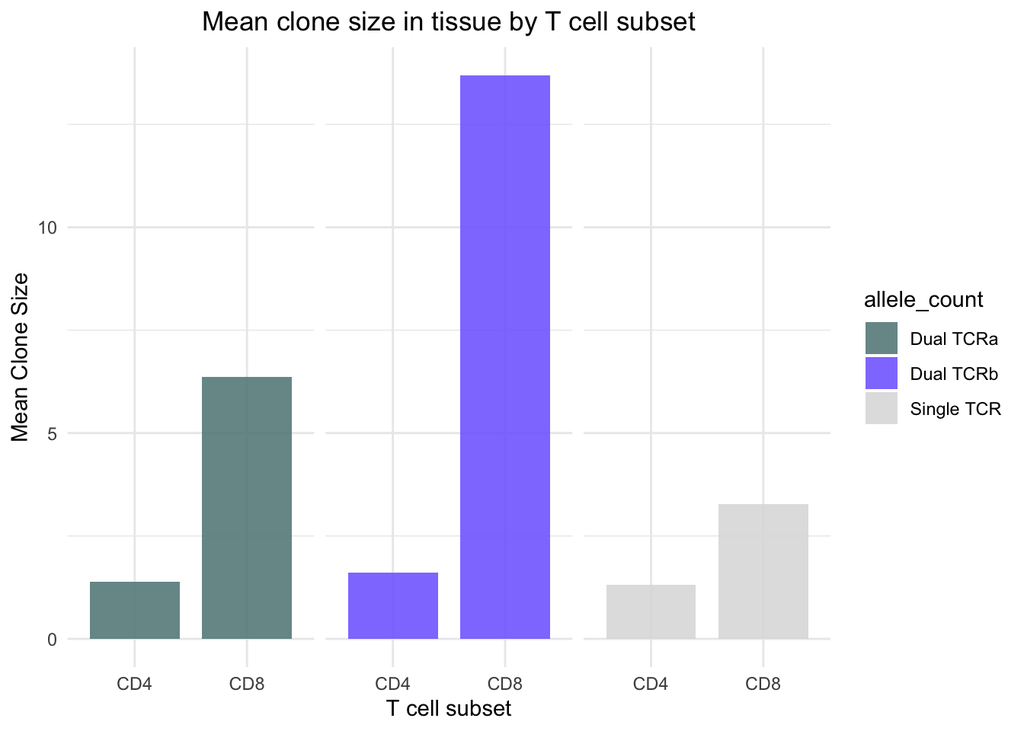

#### By T cell cluster phenotype

```r
calc_aovs_byLoc <- function (df, myList, allele) {
  # This function performs Welch's ANOVA on cloneSize by location by cluster ID
  for (i in 1:length(myList)) {
    this.cluster <- clusterNames[i]
    this.subset <- subset(df, subset = cluster.name == this.cluster & allele_count == allele)

    tryCatch(
      expr = {
        this.aov <- anovaOneW(data = this.subset, deps = cloneSize, group = loc, phMethod = "gamesHowell")
      },
      error = function(e) {
        message(paste0("Unsuccesful attempt to evaluate cluster ", this.cluster))
        print(e)
      },
      finally = {
        print(this.cluster)
        print(this.aov)
      })
  }
}
```

Many T cell clusters were similar in clonal expansion between tumor and normal tissues. A few, unsurprisingly, were different (more expanded Tregs in tumor, for example).

Clusters with significantly different **dual TCRa** mean clone size between tumor and normal tissue include:  
CD4.c17(IFNG+ Tfh/Th1), pvalue = 0.0003910  
CD4.c20(TNFRSF9+ Treg), pvalue = 0.0007275  
CD8.c12(terminal Tex), pvalue = 0.0271305

Clusters with significantly different **dual TCRb** mean clone size between tumor and normal tissue include:  
CD4.c20(TNFRSF9+ Treg), pvalue = 0.0002099

Clusters with significantly different **single TCR** mean clone size between tumor and normal tissue include:  
CD4.c05(TNF+ T), pvalue = 0.0065341  
CD4.c14(CCR6+ Th17), pvalue = 0.0388218  
CD4.c16(IL21+ Tfh), pvalue = 0.0004987  
CD4.c19(S1PR1+ Treg), pvalue = 0.0429657  
CD4.c20(TNFRSF9+ Treg), pvalue = 0.0000009  
CD4.c21(ISG+ Treg), pvalue = 0.0002077  
CD4.c22(ISG+ Th), pvalue = 0.0148291  
CD4.c23(NME1+CCR4- T), pvalue = 0.0069151  
CD8.c03(uncharacterized), pvalue = 0.0267355

```r
# Get a list of cluster IDs
clusterNames <- data.frame(table(unique_tcr_annot$cluster.name))$Var1

#Dual TCRa
calc_aovs_byLoc(unique_tcr_annot, clusterNames, allele = "Dual TCRa")
#Dual TCRb
calc_aovs_byLoc(unique_tcr_annot, clusterNames, allele = "Dual TCRb")
#Single TCR
calc_aovs_byLoc(unique_tcr_annot, clusterNames, allele = "Single TCR")
```

#### By allele count in tissue

Initial analysis indicated that dual TCR clones were more expanded (larger mean clone size) in tissue compared to single TCR clones, regardless of whether normal or tumor. To determine whether certain T cell clusters were more or less expanded, the mean clone size was calculated for dual and single TCR clones for each cluster.

Clusters with significantly different mean clone size > 2-fold include:

Dual TCRb vs single:  
CD8.c05(GZMK+ early Tem)  
CD8.c10(ZNF683+CXCR6+ Trm)  
CD8.c12(terminal Tex)  
CD8.c17(NME1+ T)

Thus, CD8+ T cells with highly differentiated phenotypes (memory and exhausted) that express more than one TCR beta chain have a higher mean clone size than CD8+ T cells expressing only one TCR beta chain. This could result from a propensity of dual expressing cells to differentiate into tissue resident memory cells, greater clonal expansion within tissue, or heightened ability to migrate into tissues and be retained there.

```r
# Perform Welch's ANOVA on cloneSize by allele count by cluster ID
calc_aovs_byAllele <- function (df, myList) {
  for (i in 1:length(myList)) {
    this.cluster <- clusterNames[i]
    this.subset <- subset(df,
                          subset = cluster.name == this.cluster & allele_count != "Dual TCRa and TCRb" & loc != "P")
    this.aov <- anovaOneW(data = this.subset, deps = cloneSize,
                          group = allele_count, phMethod = "gamesHowell")
    print(this.cluster)
    print(this.aov)
  }
}
```

```r
# Get a list of cluster IDs
clusterNames <- data.frame(table(unique_tcr_annot$cluster.name))$Var1

calc_aovs_byAllele(unique_tcr_annot, clusterNames)
```

##### Tables of significant findings (by allele count)

[figure not shown]

```r
# Visualize most convincing comparisons

pairwiseReshape <- function(df) {
  newDF <- data.frame(matrix(nrow = 2*dim(df)[1], ncol = 3))
  colnames(newDF) <- c("clusterID", "group", "value")

  newDF$clusterID <- rep(df$clusterID, 2)
  newDF$group <- c(rep(colnames(df)[2], dim(df)[1]),
                   rep(colnames(df)[3], dim(df)[1]))
  newDF$value <- c(df[,2], df[,3])
  return(newDF)
}

convincing <- pairwiseReshape(ratios_b[6:8,])

ggplot(convincing, aes(x = group, y=value, fill = group)) +
  geom_bar(stat="identity", alpha = 0.9, width = 0.8) +
  facet_wrap(~clusterID) +
  scale_fill_manual(values = c("lightslateblue", "gray87")) +
  theme_minimal() +
  xlab("") +
  ylab("Mean Clone Size") +
  ggtitle("Mean clone size within indicated cluster") +
  theme(plot.title = element_text(hjust = 0.5),
        axis.text.x = element_blank())
```

```r
ggsave("Fig.3 Mean clone size within indicated cluster.pdf", device = "pdf", path = "output", width = 6, height = 4)
```

### TR[A|B]V gene usage

```r
firstWord <- function(my.string) {
    unlist(strsplit(my.string, "_"))[1]
}

secondWord <-function(my.string) {
  my.string <- toString(my.string)
  as.numeric(str_extract(my.string, "\\d+"))
}

annotTRV <- function(df) {
  va1 <- sapply(sub(pattern = "\\|", "_", df$Identifier.A1), firstWord)
  va2 <- sapply(sub(pattern = "\\|", "_", df$Identifier.A2), firstWord)
  vb1 <- sapply(sub(pattern = "\\|", "_", df$Identifier.B1), firstWord)
  vb2 <- sapply(sub(pattern = "\\|", "_", df$Identifier.B2), firstWord)
  df$va1 <- va1
  df$va2 <- va2
  df$vb1 <- vb1
  df$vb2 <- vb2
  return(df)
}
countTRV <- function(df, chain) {

  if(chain == "beta") {
    v1 <- data.frame(table(df$vb1))
    v2 <- data.frame(table(df$vb2))
    geneList <- unique(c(unique(uniq_tcr$vb1), unique(uniq_tcr$vb2)))
  } else if (chain == "alpha") {
    v1 <- data.frame(table(df$va1))
    v2 <- data.frame(table(df$va2))
    geneList <- unique(c(unique(uniq_tcr$va1), unique(uniq_tcr$va2)))
  }

  geneList <- geneList[!is.na(geneList)]

  colnames(v1) <- c("gene", "clone_count_v1")
  colnames(v2) <- c("gene", "clone_count_v2")
  vb <- full_join(v1, v2, by = "gene")
  vb <- vb %>% replace(is.na(.), 0)
  vb$comb_cloneCount <- vb$clone_count_v1 + vb$clone_count_v2

  masterDF <- data.frame("gene" = geneList)
  masterDF <- full_join(masterDF, vb, by = "gene") %>% replace(is.na(.), 0)
  masterDF$order <- sapply(masterDF$gene, secondWord)
  masterDF <- masterDF[order(masterDF$order),]

  newDF <- data.frame("gene" = masterDF$gene,
                      "cloneCount"= masterDF$comb_cloneCount)
  newDF <- subset(newDF, subset = newDF$gene != "-")
  countTotal <- sum(newDF$cloneCount)
  newDF$cloneProportion <- newDF$cloneCount/countTotal


  return(newDF)
}
```

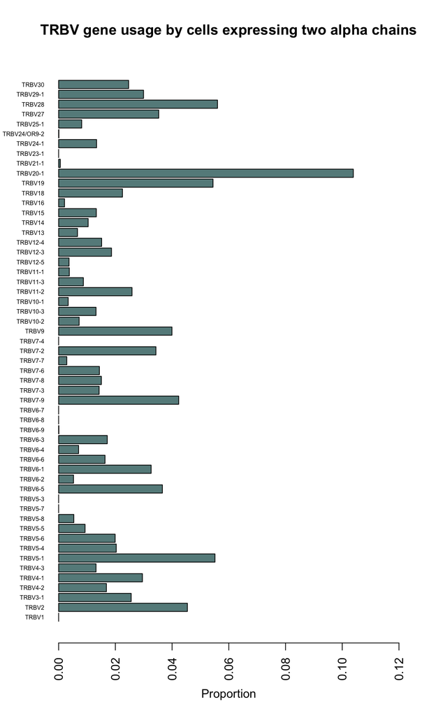

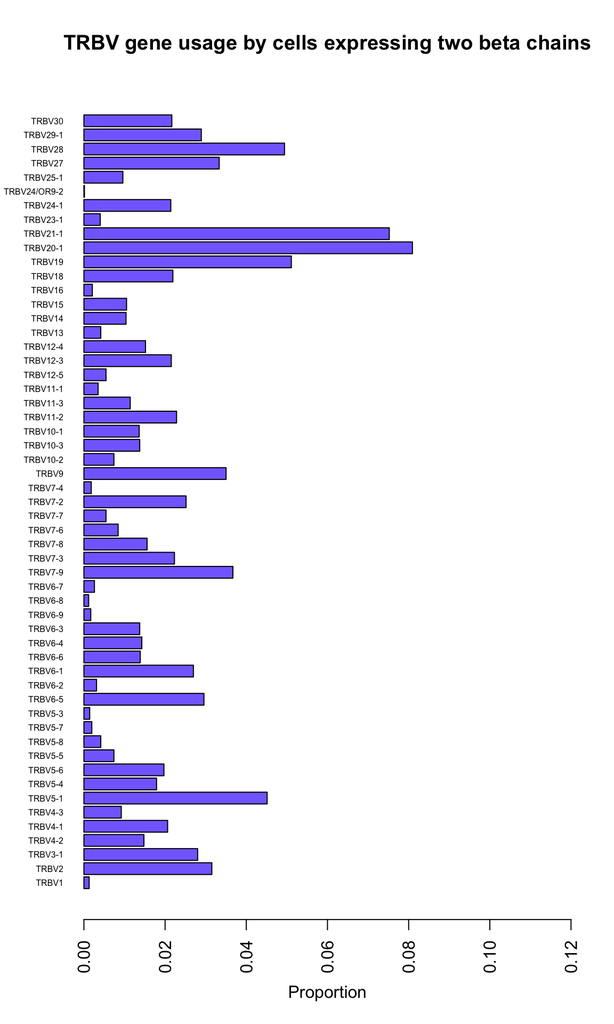

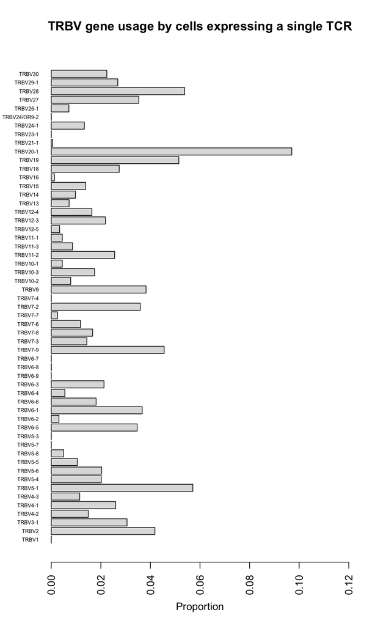

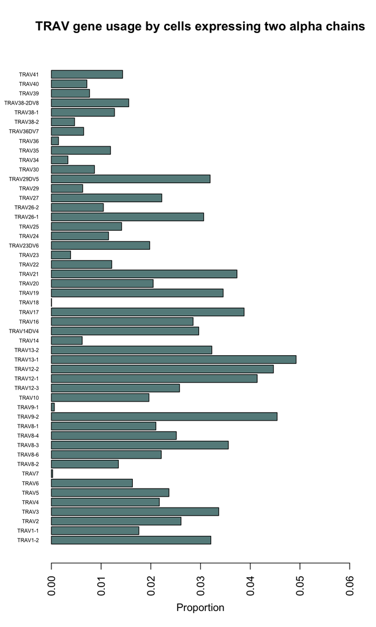

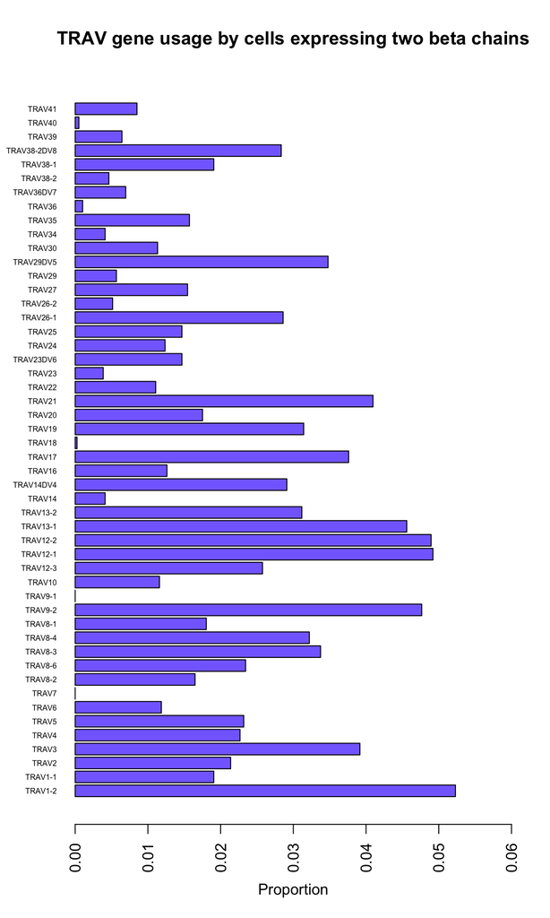

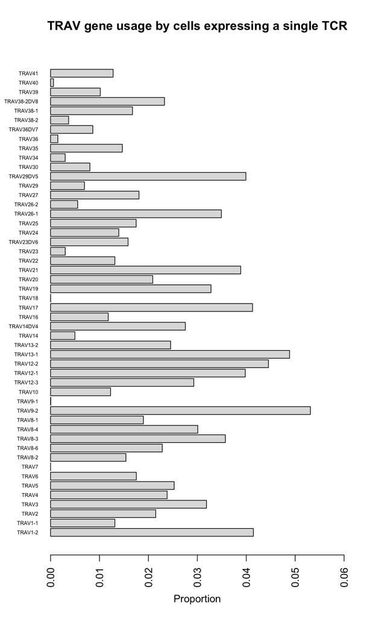